# Statistical Analysis and Document Mining TP1

Hanning Yang, Niloufar Zarghampour

## Part 1: Multiple regression on simulated data

#### 1. Set the seed of the random generator to 0 (set.seed(0)). Simulate 6, 000 × 201 = 1, 206, 000 independent random variables with the standard normal distribution. Store them into a matrix, then into a data frame with 6,000 lines and 201 columns.

```r
set.seed(0)
x <- rnorm(6000*201)
x <- matrix(x, nrow = 6000, ncol = 201, byrow = TRUE)
x <- data.frame(x)
```

#### 2. Define a Gaussian multiple linear regression model using the last 200 variables to predict the first one.

The mathematical equation of this model is as below:
$$X_1 = \beta_1 + \sum^{201}_{i=2} \beta_i X_i, \qquad
X_i \sim \mathcal{N}(0,1)$$

```r
reg = lm(X1~., data = x)
summary(reg)
```

```
##
## Call:
## lm(formula = X1 ~ ., data = x)
##
## Residuals:
##     Min      1Q  Median      3Q     Max
## -3.5596 -0.6611  0.0053  0.6404  3.8375
##
## Coefficients:
##               Estimate Std. Error t value Pr(>|t|)
## (Intercept)  1.788e-02  1.317e-02   1.357  0.17470
## X2          -1.065e-02  1.308e-02  -0.814  0.41545
## X3          -2.598e-02  1.331e-02  -1.952  0.05096 .
## X4           4.342e-03  1.331e-02   0.326  0.74424
## X5          -9.688e-03  1.327e-02  -0.730  0.46536
## X6           2.512e-03  1.304e-02   0.193  0.84727
## X7           9.434e-03  1.308e-02   0.721  0.47078
## X8           4.457e-03  1.307e-02   0.341  0.73312
## X9          -2.859e-04  1.299e-02  -0.022  0.98244
## X10          1.052e-02  1.325e-02   0.794  0.42721
## X11          7.810e-03  1.336e-02   0.584  0.55891
## X12         -1.415e-02  1.310e-02  -1.080  0.28027
## X13          1.077e-02  1.330e-02   0.810  0.41807
## X14          1.280e-02  1.316e-02   0.973  0.33075
## X15         -1.183e-02  1.295e-02  -0.913  0.36123
## X16         -2.634e-03  1.344e-02  -0.196  0.84464
## X17         -1.872e-02  1.320e-02  -1.418  0.15612
## X18         -1.817e-02  1.332e-02  -1.365  0.17242
## X19         -1.412e-02  1.299e-02  -1.086  0.27733
## X20          4.741e-03  1.302e-02   0.364  0.71576
## X21          1.969e-02  1.308e-02   1.505  0.13232
## X22         -1.322e-03  1.322e-02  -0.100  0.92030
## X23          1.095e-02  1.301e-02   0.841  0.40022
## X24          8.269e-03  1.310e-02   0.631  0.52786
## X25          7.144e-03  1.302e-02   0.549  0.58322
## X26          8.362e-03  1.302e-02   0.642  0.52073
## X27          5.254e-03  1.315e-02   0.400  0.68942
## X28         -1.212e-02  1.324e-02  -0.915  0.35998
## X29         -1.593e-03  1.302e-02  -0.122  0.90265
## X30          1.059e-02  1.324e-02   0.800  0.42379
```

[output cut: 162 more lines]

```
## X193         1.602e-03  1.315e-02   0.122  0.90308
## X194         5.661e-03  1.327e-02   0.426  0.66981
## X195         2.160e-03  1.304e-02   0.166  0.86847
## X196         2.807e-03  1.297e-02   0.216  0.82868
## X197         3.658e-02  1.320e-02   2.772  0.00560 **
## X198        -2.023e-02  1.300e-02  -1.556  0.11968
## X199         2.133e-03  1.293e-02   0.165  0.86897
## X200        -2.112e-02  1.310e-02  -1.613  0.10685
## X201         2.706e-02  1.309e-02   2.067  0.03876 *
## ---
## Signif. codes:  0 '***' 0.001 '**' 0.01 '*' 0.05 '.' 0.1 ' ' 1
##
## Residual standard error: 1.002 on 5799 degrees of freedom
## Multiple R-squared:  0.03717,    Adjusted R-squared:  0.003964
## F-statistic: 1.119 on 200 and 5799 DF,  p-value: 0.1231
```

#### 3. Estimate the parameters of the linear model using the last 200 variables to predict the first one. Compute the number of coefficients assessed as significantly non-zero at level 5%.

```r
summary(reg)$coefficients
```

```
##                  Estimate Std. Error      t value    Pr(>|t|)
## (Intercept)  1.787645e-02 0.01316940  1.357423248 0.174699589
## X2          -1.064957e-02 0.01307670 -0.814393267 0.415453136
## X3          -2.598123e-02 0.01330841 -1.952241034 0.050957650
## X4           4.341779e-03 0.01330750  0.326265454 0.744235297
## X5          -9.688345e-03 0.01326997 -0.730095620 0.465361230
## X6           2.511851e-03 0.01304127  0.192607807 0.847272875
## X7           9.434197e-03 0.01308033  0.721250540 0.470784458
## X8           4.456717e-03 0.01306963  0.340997972 0.733117462
## X9          -2.859407e-04 0.01299334 -0.022006716 0.982443355
## X10          1.052458e-02 0.01325457  0.794034362 0.427207918
## X11          7.810396e-03 0.01336276  0.584489752 0.558913595
## X12         -1.414660e-02 0.01310109 -1.079803099 0.280274778
## X13          1.076908e-02 0.01329784  0.809836610 0.418067317
## X14          1.280443e-02 0.01316392  0.972691137 0.330747401
## X15         -1.182853e-02 0.01295442 -0.913087675 0.361234391
## X16         -2.634362e-03 0.01344267 -0.195970214 0.844640346
## X17         -1.871934e-02 0.01319741 -1.418410199 0.156124777
## X18         -1.817291e-02 0.01331714 -1.364625419 0.172423759
## X19         -1.411790e-02 0.01299457 -1.086446258 0.277326763
## X20          4.740922e-03 0.01301901  0.364153774 0.715756460
## X21          1.969237e-02 0.01308266  1.505226388 0.132320346
## X22         -1.322475e-03 0.01321623 -0.100064507 0.920296572
## X23          1.094766e-02 0.01301281  0.841298865 0.400215216
## X24          8.269328e-03 0.01309867  0.631310546 0.527862375
## X25          7.143970e-03 0.01301952  0.548712135 0.583224141
## X26          8.361709e-03 0.01301921  0.642259350 0.520730192
## X27          5.253621e-03 0.01314511  0.399663530 0.689419076
## X28         -1.212351e-02 0.01324293 -0.915470570 0.359982711
## X29         -1.593126e-03 0.01302404 -0.122321948 0.902648289
## X30          1.058973e-02 0.01323848  0.799920065 0.423789878
## X31          3.608762e-02 0.01325593  2.722375803 0.006500816
## X32          8.538194e-03 0.01325097  0.644344995 0.519377229
## X33          1.212403e-03 0.01311341  0.092455143 0.926339623
## X34         -2.448741e-02 0.01332156 -1.838179636 0.066087057
## X35          1.272128e-02 0.01311084  0.970287097 0.331943874
## X36         -3.138079e-03 0.01328161 -0.236272428 0.813229625
## X37          4.471136e-03 0.01309084  0.341546893 0.732704284
## X38          1.070380e-02 0.01307838  0.818434302 0.413142871
## X39         -1.405895e-02 0.01309233 -1.073830387 0.282943388
```

[output cut: 147 more lines]

```
## X187        -7.729540e-03 0.01309544 -0.590246588 0.555048342
## X188         5.169560e-03 0.01328429  0.389148449 0.697180624
## X189        -4.555632e-03 0.01332358 -0.341922450 0.732421645
## X190        -1.067202e-02 0.01326889 -0.804289143 0.421262976
## X191         9.434749e-03 0.01308093  0.721259664 0.470778846
## X192        -1.039529e-02 0.01313008 -0.791715845 0.428558763
## X193         1.601691e-03 0.01315324  0.121771656 0.903084081
## X194         5.660551e-03 0.01327447  0.426423794 0.669814894
## X195         2.159578e-03 0.01304056  0.165604685 0.868473833
## X196         2.806623e-03 0.01296941  0.216403346 0.828680970
## X197         3.657868e-02 0.01319744  2.771649629 0.005595089
## X198        -2.023417e-02 0.01300094 -1.556362266 0.119676542
## X199         2.132738e-03 0.01292744  0.164977604 0.868967361
## X200        -2.112393e-02 0.01309799 -1.612760629 0.106850937
## X201         2.706434e-02 0.01309234  2.067189528 0.038760568
```

```r
confint(reg, level = 0.95)
```

```
##                     2.5 %        97.5 %
## (Intercept) -0.0079404901  0.0436933968
## X2          -0.0362847820  0.0149856327
## X3          -0.0520706773  0.0001082256
## X4          -0.0217458957  0.0304294538
## X5          -0.0357024310  0.0163257419
## X6          -0.0230539124  0.0280776148
## X7          -0.0162081353  0.0350765286
## X8          -0.0211646348  0.0300780697
## X9          -0.0257577323  0.0251858509
## X10         -0.0154593152  0.0365084779
## X11         -0.0183855990  0.0340063910
## X12         -0.0398296191  0.0115364265
## X13         -0.0152996472  0.0368377975
## X14         -0.0130017702  0.0386106330
## X15         -0.0372240304  0.0135669803
## X16         -0.0289870027  0.0237182786
## X17         -0.0445911792  0.0071525057
## X18         -0.0442794782  0.0079336572
## X19         -0.0395920941  0.0113563002
## X20         -0.0207811958  0.0302630389
## X21         -0.0059545306  0.0453392626
## X22         -0.0272312148  0.0245862640
## X23         -0.0145623038  0.0364576324
## X24         -0.0174089506  0.0339476059
## X25         -0.0183791517  0.0326670912
## X26         -0.0171607987  0.0338842158
## X27         -0.0205156986  0.0310229402
## X28         -0.0380846040  0.0138375743
## X29         -0.0271251013  0.0239388498
## X30         -0.0153626342  0.0365420847
## X31          0.0101010541  0.0620741940
## X32         -0.0174386459  0.0345150347
## X33         -0.0244947837  0.0269195890
## X34         -0.0506026340  0.0016278078
## X35         -0.0129808595  0.0384234166
## X36         -0.0291750001  0.0228988414
## X37         -0.0211917961  0.0301340679
## X38         -0.0149347121  0.0363423043
## X39         -0.0397248037  0.0116069132
```

[output cut: 147 more lines]

```
## X187        -0.0334014919  0.0179424124
## X188        -0.0208726031  0.0312117240
## X189        -0.0306748263  0.0215635621
## X190        -0.0366839884  0.0153399467
## X191        -0.0162087607  0.0350782596
## X192        -0.0361351412  0.0153445607
## X193        -0.0241835619  0.0273869449
## X194        -0.0203623696  0.0316834720
## X195        -0.0234047929  0.0277239499
## X196        -0.0226182543  0.0282315004
## X197         0.0107067715  0.0624505798
## X198        -0.0457208710  0.0052525218
## X199        -0.0232098664  0.0274753422
## X200        -0.0468008874  0.0045530270
## X201         0.0013984758  0.0527302002
```

We are using $\alpha = 0.05$ to determine which predictors are significant in this regression model. As we can see from the generated result, most of the predictors are statistically insignificant. Multiple R-Squared tells us the proportion of the variance in the response variable that can be explained by the predictor variables. The closer it is to 1, the better the predictor variables are able to predict the value of the response variable. However, in our example, the value equals to 0.03717. Thus, the predictors cannot predict the response value well. Moreover, p-value is greatly larger than 0.05. Hence, we can conclude that the predictor variables are notuseful for predicting the value of the response variable.

#### 4. Simulate a sample of size n = 1000 of the following model:

$$X_{1,i} = \epsilon_{1,i} \\
X_{2,i} = 3X_{1,i} + \epsilon_{2,i} \\
Y_i = X_{2,i} + X_{1,i} + 2 + \epsilon_{3,i}$$

```r
n <- 1000
x1 <- rnorm(n)
x2 <- 3*x1 + rnorm(n)
y <- x2 + x1 + 2 + rnorm(n)
df2 <- data.frame(x1,x2,y)
lm2 <- lm(y~.,data=df2)
summary(lm2)
```

```
##
## Call:
## lm(formula = y ~ ., data = df2)
##
## Residuals:
##     Min      1Q  Median      3Q     Max
## -4.2215 -0.6680  0.0320  0.6576  2.8570
##
## Coefficients:
##             Estimate Std. Error t value Pr(>|t|)
## (Intercept)  2.02016    0.03063   65.95   <2e-16 ***
## x1           1.10930    0.09639   11.51   <2e-16 ***
## x2           0.96875    0.03010   32.19   <2e-16 ***
## ---
## Signif. codes:  0 '***' 0.001 '**' 0.01 '*' 0.05 '.' 0.1 ' ' 1
##
## Residual standard error: 0.9682 on 997 degrees of freedom
## Multiple R-squared:  0.9494, Adjusted R-squared:  0.9493
## F-statistic:  9355 on 2 and 997 DF,  p-value: < 2.2e-16
```

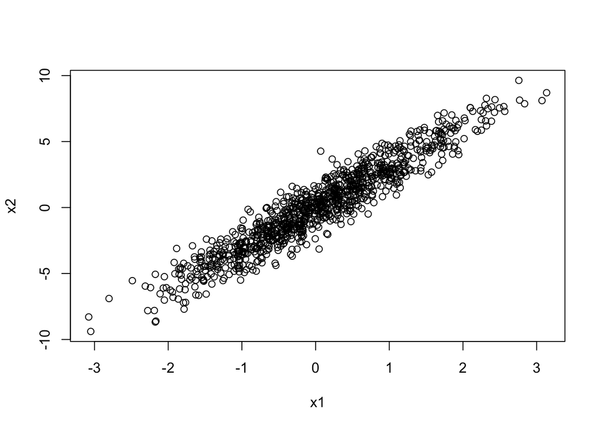

```r
plot(x1,x2)
```

Both of $X_{1,i}$ and $X_{2,i}$ have normal distribution.
$$X_{1,i} \sim N(0,1) \qquad X_{2,i} \sim N(0,10)$$
The shape of the clouds of points of the simulated values of $(X_{1,i}, X_{2,i})$ is ellipse. This is expected from the fact that the formula for the density function is a quadratic form in the variables. It is also seen in the plot that the center of the point cloud is quite close to the true means of the variables, namely 0.

#### 5. Let us consider the following 2 models:

Model 1: $Y_i = \beta_1 X_{1,i} + \beta_0 + \tilde{\epsilon}_{1,i}$

Model 2: $Y_i = \beta_2 X_{2,i} + \beta_0 + \tilde{\epsilon}_{2,i}$  
where $i ∈ {1, . . . , n}$ and the $\epsilon_i$ are independent N (0,$\sigma^2$) random variables.

```r
df3 <- data.frame(x1,y)
df4 <- data.frame(x2,y)
lm3 <- lm(y~x1,data = df3)
lm4 <- lm(y~x2,data = df4)
summary(lm3)
```

```
##
## Call:
## lm(formula = y ~ x1, data = df3)
##
## Residuals:
##     Min      1Q  Median      3Q     Max
## -5.0203 -0.8801  0.0358  0.9690  4.4167
##
## Coefficients:
##             Estimate Std. Error t value Pr(>|t|)
## (Intercept)  2.01065    0.04371   45.99   <2e-16 ***
## x1           4.05262    0.04351   93.14   <2e-16 ***
## ---
## Signif. codes:  0 '***' 0.001 '**' 0.01 '*' 0.05 '.' 0.1 ' ' 1
##
## Residual standard error: 1.382 on 998 degrees of freedom
## Multiple R-squared:  0.8968, Adjusted R-squared:  0.8967
## F-statistic:  8676 on 1 and 998 DF,  p-value: < 2.2e-16
```

```r
summary(lm4)
```

```
##
## Call:
## lm(formula = y ~ x2, data = df4)
##
## Residuals:
##     Min      1Q  Median      3Q     Max
## -4.0205 -0.7049  0.0432  0.7061  2.9802
##
## Coefficients:
##             Estimate Std. Error t value Pr(>|t|)
## (Intercept)  2.02616    0.03258   62.19   <2e-16 ***
## x2           1.29734    0.01013  128.12   <2e-16 ***
## ---
## Signif. codes:  0 '***' 0.001 '**' 0.01 '*' 0.05 '.' 0.1 ' ' 1
##
## Residual standard error: 1.03 on 998 degrees of freedom
## Multiple R-squared:  0.9427, Adjusted R-squared:  0.9426
## F-statistic: 1.642e+04 on 1 and 998 DF,  p-value: < 2.2e-16
```

```r
set.seed(3)
n <- 10
x1 <- rnorm(n)
x2 <- 3*x1 + rnorm(n)
y <- x2 + x1 + 2 + rnorm(n)
df5 <- data.frame(x1,x2,y)
lm5 <- lm(y~.,data=df5)
summary(lm5)
```

```
##
## Call:
## lm(formula = y ~ ., data = df5)
##
## Residuals:
##      Min       1Q   Median       3Q      Max
## -0.99896 -0.66387 -0.09066  0.71179  1.30298
##
## Coefficients:
##             Estimate Std. Error t value Pr(>|t|)
## (Intercept)   1.5812     0.3234   4.890  0.00177 **
## x1            2.0628     1.2974   1.590  0.15588
## x2            0.7336     0.4519   1.623  0.14855
## ---
## Signif. codes:  0 '***' 0.001 '**' 0.01 '*' 0.05 '.' 0.1 ' ' 1
##
## Residual standard error: 0.9357 on 7 degrees of freedom
## Multiple R-squared:  0.9494, Adjusted R-squared:  0.9349
## F-statistic: 65.63 on 2 and 7 DF,  p-value: 2.92e-05
```

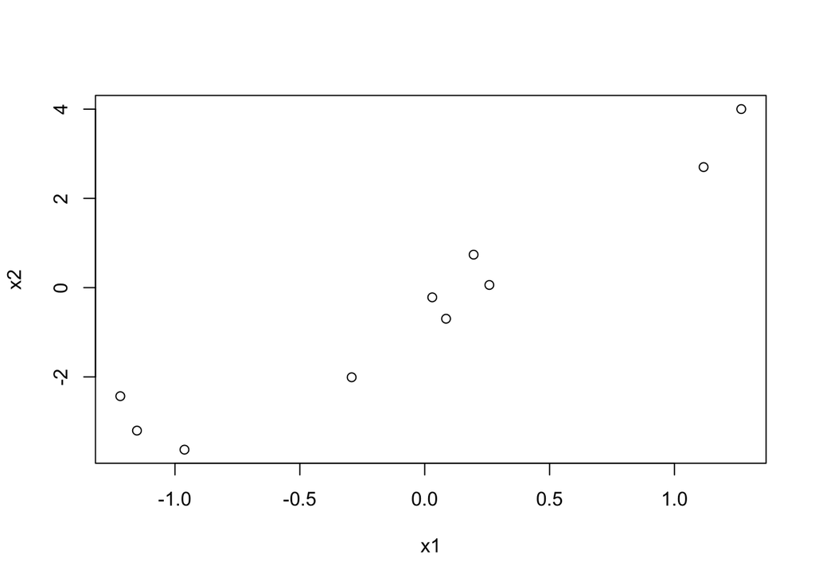

```r
plot(x1,x2)
```

```r
lm6 <- lm(y~x1,data.frame(x1,y))
lm7 <- lm(y~x2,data.frame(x2,y))
summary(lm6)
```

```
##
## Call:
## lm(formula = y ~ x1, data = data.frame(x1, y))
##
## Residuals:
##     Min      1Q  Median      3Q     Max
## -1.4216 -0.5664 -0.3675  0.6896  1.8840
##
## Coefficients:
##             Estimate Std. Error t value Pr(>|t|)
## (Intercept)   1.3733     0.3258   4.215  0.00294 **
## x1            4.0861     0.3954  10.334 6.64e-06 ***
## ---
## Signif. codes:  0 '***' 0.001 '**' 0.01 '*' 0.05 '.' 0.1 ' ' 1
##
## Residual standard error: 1.027 on 8 degrees of freedom
## Multiple R-squared:  0.9303, Adjusted R-squared:  0.9216
## F-statistic: 106.8 on 1 and 8 DF,  p-value: 6.637e-06
```

```r
summary(lm7)
```

```
##
## Call:
## lm(formula = y ~ x2, data = data.frame(x2, y))
##
## Residuals:
##     Min      1Q  Median      3Q     Max
## -1.3320 -0.3809 -0.0879  0.2556  1.7751
##
## Coefficients:
##             Estimate Std. Error t value Pr(>|t|)
## (Intercept)   1.7662     0.3292   5.365 0.000674 ***
## x2            1.4239     0.1370  10.397 6.34e-06 ***
## ---
## Signif. codes:  0 '***' 0.001 '**' 0.01 '*' 0.05 '.' 0.1 ' ' 1
##
## Residual standard error: 1.021 on 8 degrees of freedom
## Multiple R-squared:  0.9311, Adjusted R-squared:  0.9225
## F-statistic: 108.1 on 1 and 8 DF,  p-value: 6.344e-06
```

When we decrease the number of training data, the estimations are deviated from the true value.

#### 6. Let us now consider the model:

$$Y_i = \beta_2X_{2,i} + \beta_1X_{1,i} + \beta_0 + \epsilon_i$$
where $i ∈ {1, . . . , n}$ and the $\epsilon_i$ are independent N (0, $\sigma_2$) random variables. For the previously simulated data with n = 10, estimate the parameters $\beta_0, \beta_1, \beta_2, \sigma_2$.

```r
lm8 <- lm(y~x1+x2, data.frame(x1,x2,y))
summary(lm8)
```

```
##
## Call:
## lm(formula = y ~ x1 + x2, data = data.frame(x1, x2, y))
##
## Residuals:
##      Min       1Q   Median       3Q      Max
## -0.99896 -0.66387 -0.09066  0.71179  1.30298
##
## Coefficients:
##             Estimate Std. Error t value Pr(>|t|)
## (Intercept)   1.5812     0.3234   4.890  0.00177 **
## x1            2.0628     1.2974   1.590  0.15588
## x2            0.7336     0.4519   1.623  0.14855
## ---
## Signif. codes:  0 '***' 0.001 '**' 0.01 '*' 0.05 '.' 0.1 ' ' 1
##
## Residual standard error: 0.9357 on 7 degrees of freedom
## Multiple R-squared:  0.9494, Adjusted R-squared:  0.9349
## F-statistic: 65.63 on 2 and 7 DF,  p-value: 2.92e-05
```

## Part 2: Analysis of prostate cancer data

### 1. Preliminary analysis of the data

#### (a) Read the data

```r
prostateCancer <- read.table("./prostate.data", header=T)
attach(prostateCancer)
prostateCancer$lcavol  <- scale( lcavol )
prostateCancer$lweight <- scale( lweight )
prostateCancer$age     <- scale( age )
prostateCancer$lbph    <- scale( lbph )
prostateCancer$svi     <- scale( svi )
prostateCancer$lcp     <- scale( lcp )
prostateCancer$pgg45   <- scale( pgg45 )
prostateCancer$gleason <- scale( gleason )
prostateCancer = data.frame(prostateCancer)
pro <- prostateCancer[,-10]
summary(pro)
```

```
##       lcavol.V1            lweight.V1             age.V1
##  Min.   :-2.2883305   Min.   :-2.9271797   Min.   :-3.0712720
##  1st Qu.:-0.7103074   1st Qu.:-0.5907003   1st Qu.:-0.5192637
##  Median : 0.0822224   Median :-0.0138551   Median : 0.1523174
##  Mean   : 0.0000000   Mean   : 0.0000000   Mean   : 0.0000000
##  3rd Qu.: 0.6592691   3rd Qu.: 0.5776070   3rd Qu.: 0.5552660
##  Max.   : 2.0965059   Max.   : 2.6876988   Max.   : 2.0327445
##        lbph.V1               svi.V1               lcp.V1
##  Min.   :-1.0247058   Min.   :-0.5229409   Min.   :-0.8631712
##  1st Qu.:-1.0247058   1st Qu.:-0.5229409   1st Qu.:-0.8631712
##  Median : 0.1376813   Median :-0.5229409   Median :-0.4427980
##  Mean   : 0.0000000   Mean   : 0.0000000   Mean   : 0.0000000
##  3rd Qu.: 1.0048128   3rd Qu.:-0.5229409   3rd Qu.: 0.9712290
##  Max.   : 1.5342817   Max.   : 1.8925480   Max.   : 2.2052791
##       gleason.V1            pgg45.V1            lpsa
##  Min.   :-1.0421573   Min.   :-0.8644665   Min.   :-0.4308
##  1st Qu.:-1.0421573   1st Qu.:-0.8644665   1st Qu.: 1.7317
##  Median : 0.3426271   Median :-0.3326277   Median : 2.5915
##  Mean   : 0.0000000   Mean   : 0.0000000   Mean   : 2.4784
##  3rd Qu.: 0.3426271   3rd Qu.: 0.5537703   3rd Qu.: 3.0564
##  Max.   : 3.1121957   Max.   : 2.6811255   Max.   : 5.5829
```

#### (b) Analyse the correlations between all the variables and identify the variables which are the most correlated to lcavol.

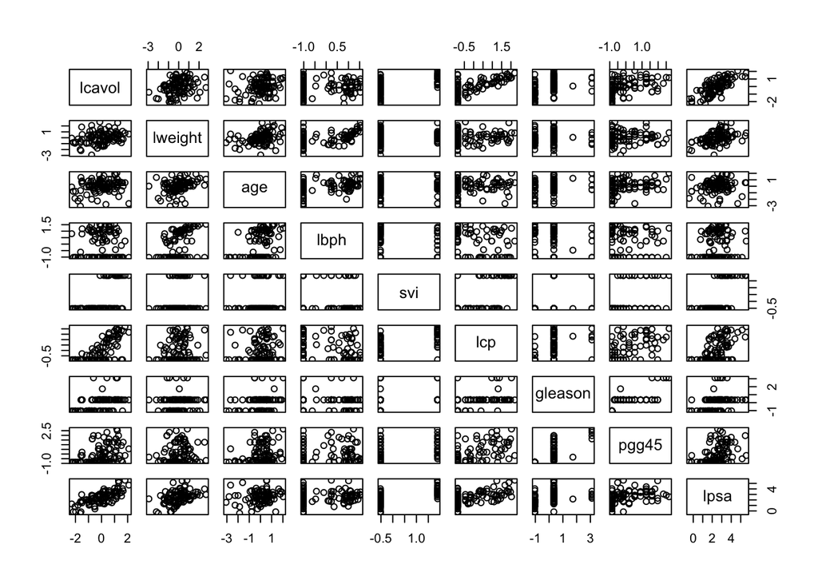

```r
pairs(pro)
```

```r
#corre <- cor( prostateCancer[1:7] )

pro.cor = cor(pro)
# looking for the strongest correlation with lcavol :
# first , rounding each cor value to 3 digits then sorting is performed
round(pro.cor,3)
```

```
##         lcavol lweight   age   lbph    svi    lcp gleason pgg45  lpsa
## lcavol   1.000   0.281 0.225  0.027  0.539  0.675   0.432 0.434 0.734
## lweight  0.281   1.000 0.348  0.442  0.155  0.165   0.057 0.107 0.433
## age      0.225   0.348 1.000  0.350  0.118  0.128   0.269 0.276 0.170
## lbph     0.027   0.442 0.350  1.000 -0.086 -0.007   0.078 0.078 0.180
## svi      0.539   0.155 0.118 -0.086  1.000  0.673   0.320 0.458 0.566
## lcp      0.675   0.165 0.128 -0.007  0.673  1.000   0.515 0.632 0.549
## gleason  0.432   0.057 0.269  0.078  0.320  0.515   1.000 0.752 0.369
## pgg45    0.434   0.107 0.276  0.078  0.458  0.632   0.752 1.000 0.422
## lpsa     0.734   0.433 0.170  0.180  0.566  0.549   0.369 0.422 1.000
```

```r
pro.cor = pro.cor[1,]
pro.cor[upper.tri(pro.cor,diag=T)] = 0
pro.cor.sorted = sort(abs(pro.cor),decreasing=T)

#finding the column names with the highest correlation
k = which(pro.cor == pro.cor.sorted[1])
print(paste("The first highest correlation with lcoval is with the variable ",colnames(pro)[k], " and the value of that correlation is ",pro.cor.sorted[1] ))
```

```
## [1] "The first highest correlation with lcoval is with the variable  lpsa  and the value of that correlation is  0.734460326213673"
```

From the correlation values, we obtained that svi, lcp and lpsa are the most correlated to lcavol.

### 2. Linear regression

#### (a) Perform a multiple linear regression to build a predictive model for the lcavol variable.

```r
pro$gleason<-factor(pro$gleason)
pro$svi<-factor(pro$svi)
pro$gleason
```

```
##  [1] -1.04215728919298 -1.04215728919298 0.342627053981254 -1.04215728919298
##  [5] -1.04215728919298 -1.04215728919298 -1.04215728919298 -1.04215728919298
##  [9] -1.04215728919298 -1.04215728919298 -1.04215728919298 -1.04215728919298
## [13] 0.342627053981254 0.342627053981254 0.342627053981254 -1.04215728919298
## [17] 0.342627053981254 -1.04215728919298 -1.04215728919298 -1.04215728919298
## [21] -1.04215728919298 0.342627053981254 -1.04215728919298 0.342627053981254
## [25] -1.04215728919298 -1.04215728919298 0.342627053981254 0.342627053981254
## [29] 0.342627053981254 -1.04215728919298 -1.04215728919298 -1.04215728919298
## [33] -1.04215728919298 -1.04215728919298 -1.04215728919298 0.342627053981254
## [37] 1.72741139715549  0.342627053981254 0.342627053981254 0.342627053981254
## [41] 3.11219574032972  0.342627053981254 -1.04215728919298 0.342627053981254
## [45] 0.342627053981254 0.342627053981254 3.11219574032972  0.342627053981254
## [49] -1.04215728919298 -1.04215728919298 0.342627053981254 -1.04215728919298
## [53] 0.342627053981254 0.342627053981254 0.342627053981254 0.342627053981254
## [57] 0.342627053981254 -1.04215728919298 0.342627053981254 0.342627053981254
## [61] -1.04215728919298 0.342627053981254 3.11219574032972  0.342627053981254
## [65] -1.04215728919298 0.342627053981254 0.342627053981254 0.342627053981254
## [69] -1.04215728919298 0.342627053981254 0.342627053981254 0.342627053981254
## [73] 0.342627053981254 3.11219574032972  0.342627053981254 0.342627053981254
## [77] 0.342627053981254 0.342627053981254 0.342627053981254 0.342627053981254
## [81] 0.342627053981254 0.342627053981254 0.342627053981254 3.11219574032972
## [85] 0.342627053981254 0.342627053981254 -1.04215728919298 0.342627053981254
## [89] 0.342627053981254 0.342627053981254 -1.04215728919298 0.342627053981254
## [93] 0.342627053981254 0.342627053981254 0.342627053981254 0.342627053981254
## [97] 0.342627053981254
## 4 Levels: -1.04215728919298 0.342627053981254 ... 3.11219574032972
```

```r
pro$svi
```

```
##  [1] -0.522940888712441 -0.522940888712441 -0.522940888712441 -0.522940888712441
##  [5] -0.522940888712441 -0.522940888712441 -0.522940888712441 -0.522940888712441
##  [9] -0.522940888712441 -0.522940888712441 -0.522940888712441 -0.522940888712441
## [13] -0.522940888712441 -0.522940888712441 -0.522940888712441 -0.522940888712441
## [17] -0.522940888712441 -0.522940888712441 -0.522940888712441 -0.522940888712441
## [21] -0.522940888712441 -0.522940888712441 -0.522940888712441 -0.522940888712441
## [25] -0.522940888712441 -0.522940888712441 -0.522940888712441 -0.522940888712441
## [29] -0.522940888712441 -0.522940888712441 -0.522940888712441 -0.522940888712441
## [33] -0.522940888712441 -0.522940888712441 -0.522940888712441 -0.522940888712441
## [37] -0.522940888712441 -0.522940888712441 1.89254797819741   -0.522940888712441
## [41] -0.522940888712441 -0.522940888712441 -0.522940888712441 -0.522940888712441
## [45] -0.522940888712441 -0.522940888712441 1.89254797819741   -0.522940888712441
## [49] -0.522940888712441 -0.522940888712441 -0.522940888712441 -0.522940888712441
## [53] -0.522940888712441 -0.522940888712441 -0.522940888712441 -0.522940888712441
## [57] -0.522940888712441 -0.522940888712441 -0.522940888712441 -0.522940888712441
## [61] -0.522940888712441 1.89254797819741   -0.522940888712441 1.89254797819741
## [65] -0.522940888712441 -0.522940888712441 -0.522940888712441 -0.522940888712441
## [69] -0.522940888712441 -0.522940888712441 1.89254797819741   -0.522940888712441
## [73] 1.89254797819741   1.89254797819741   1.89254797819741   1.89254797819741
## [77] -0.522940888712441 -0.522940888712441 1.89254797819741   -0.522940888712441
## [81] -0.522940888712441 -0.522940888712441 1.89254797819741   -0.522940888712441
## [85] -0.522940888712441 1.89254797819741   -0.522940888712441 1.89254797819741
## [89] 1.89254797819741   1.89254797819741   -0.522940888712441 1.89254797819741
## [93] 1.89254797819741   1.89254797819741   1.89254797819741   1.89254797819741
## [97] 1.89254797819741
## Levels: -0.522940888712441 1.89254797819741
```

```r
regression=lm(prostateCancer$lcavol~prostateCancer$lweight+prostateCancer$age+prostateCancer$lbph+prostateCancer$svi+prostateCancer$lcp+prostateCancer$gleason+prostateCancer$pgg45+prostateCancer$lpsa)
summary(regression)
```

```
##
## Call:
## lm(formula = prostateCancer$lcavol ~ prostateCancer$lweight +
##     prostateCancer$age + prostateCancer$lbph + prostateCancer$svi +
##     prostateCancer$lcp + prostateCancer$gleason + prostateCancer$pgg45 +
##     prostateCancer$lpsa)
##
## Residuals:
##      Min       1Q   Median       3Q      Max
## -1.62660 -0.40876 -0.03621  0.47560  1.58237
##
## Coefficients:
##                         Estimate Std. Error t value Pr(>|t|)
## (Intercept)            -1.189807   0.194763  -6.109 2.66e-08 ***
## prostateCancer$lweight -0.009423   0.076992  -0.122   0.9029
## prostateCancer$age      0.139684   0.069990   1.996   0.0491 *
## prostateCancer$lbph    -0.114647   0.071465  -1.604   0.1122
## prostateCancer$svi     -0.053730   0.089320  -0.602   0.5490
## prostateCancer$lcp      0.435600   0.097060   4.488 2.17e-05 ***
## prostateCancer$gleason  0.120853   0.094481   1.279   0.2042
## prostateCancer$pgg45   -0.170315   0.103637  -1.643   0.1039
## prostateCancer$lpsa     0.480073   0.074718   6.425 6.55e-09 ***
## ---
## Signif. codes:  0 '***' 0.001 '**' 0.01 '*' 0.05 '.' 0.1 ' ' 1
##
## Residual standard error: 0.5943 on 88 degrees of freedom
## Multiple R-squared:  0.6763, Adjusted R-squared:  0.6468
## F-statistic: 22.98 on 8 and 88 DF,  p-value: < 2.2e-16
```

#### (b) Give confidence intervals of level 95% for all the coefficients of the predictors。

```r
confint(regression, level = 0.95)
```

```
##                                2.5 %      97.5 %
## (Intercept)            -1.5768563837 -0.80275686
## prostateCancer$lweight -0.1624286028  0.14358194
## prostateCancer$age      0.0005933172  0.27877509
## prostateCancer$lbph    -0.2566687005  0.02737472
## prostateCancer$svi     -0.2312336683  0.12377397
## prostateCancer$lcp      0.2427146828  0.62848565
## prostateCancer$gleason -0.0669084829  0.30861454
## prostateCancer$pgg45   -0.3762730579  0.03564233
## prostateCancer$lpsa     0.3315866127  0.62855939
```

#### (c) Relate the answer to the p-value of a test and a confidence interval.

The p-value of lpsa is far lower than 0.05. Thus, lcavol and lpsa are highly correlated.

#### (d) Plot the predicted values of lcavol as a function of the actual values. Plot the histogram of residuals.

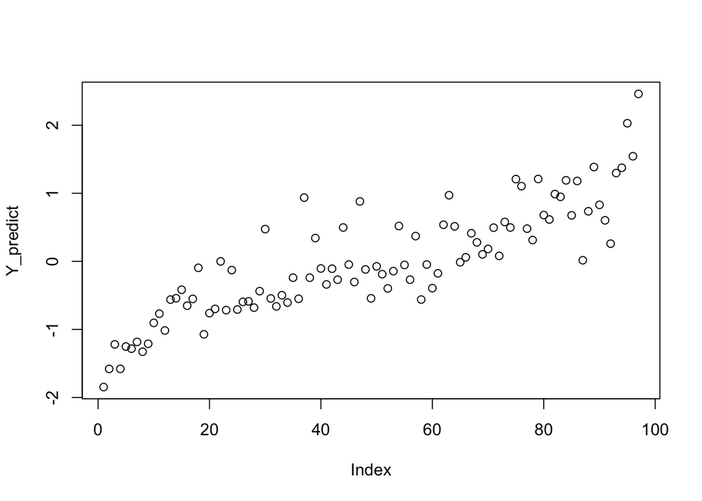

```r
Y_predict <- predict( regression)
plot(Y_predict)
```

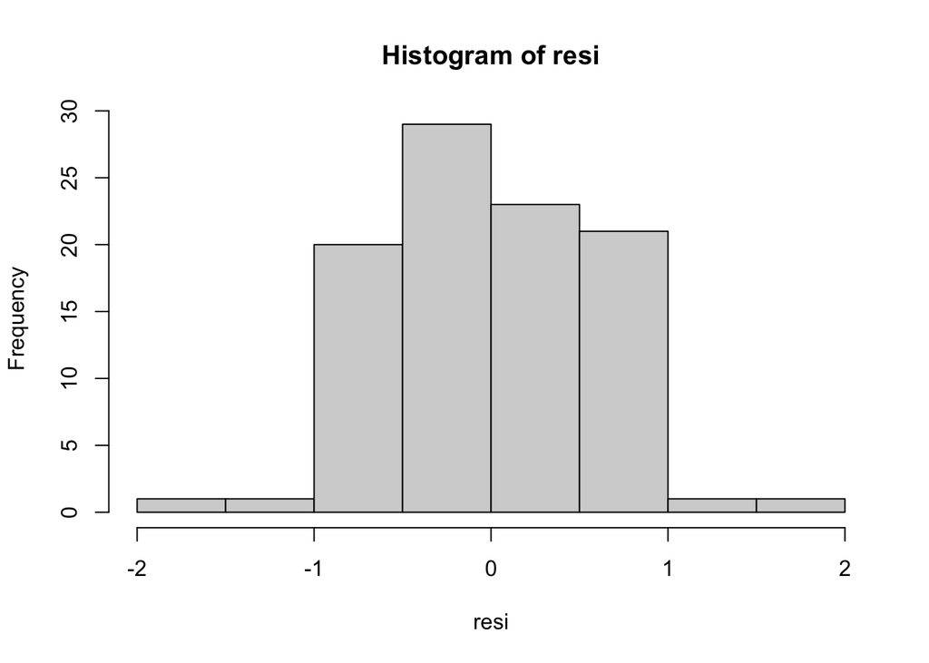

```r
resi =  pro$lcavol - Y_predict
hist(resi)
```

```r
rss = 0
for (i in length(resi)) {
  rss = rss + (prostateCancer$lcavol[i] - Y_predict[i])*(prostateCancer$lcavol[i] - Y_predict[i])
}
print(rss)
```

```
##       97
## 0.435718
```

From the histogram of residuals, it is close to normal distribution. But we cannot conclude it admits normal distribution directly.

#### (e) What do you think of the optimality of this model?

```r
sum((regression$residuals)^2)
```

```
## [1] 31.07763
```

In terms of the value of RSS, we can think the model doesn’t fit well because it is quite high.

#### (f) What happens if predictors lpsa and lcp are removed from the model?

```r
prostate_sub <- subset(pro, select = -c(lpsa, lcp))
lm_remove <- lm(formula = prostateCancer$lcavol~., data = prostate_sub)
summary(lm_remove)
```

```
##
## Call:
## lm(formula = prostateCancer$lcavol ~ ., data = prostate_sub)
##
## Residuals:
##      Min       1Q   Median       3Q      Max
## -1.56528 -0.40943 -0.01486  0.49989  1.88346
##
## Coefficients:
##                          Estimate Std. Error t value Pr(>|t|)
## (Intercept)              -0.63772    0.17696  -3.604 0.000519 ***
## lweight                   0.21262    0.09420   2.257 0.026472 *
## age                       0.04602    0.09268   0.497 0.620739
## lbph                     -0.09188    0.09500  -0.967 0.336097
## svi1.89254797819741       0.86930    0.23033   3.774 0.000291 ***
## gleason0.342627053981254  0.67939    0.23284   2.918 0.004473 **
## gleason1.72741139715549   0.58277    0.81461   0.715 0.476253
## gleason3.11219574032972   0.99493    0.54677   1.820 0.072214 .
## pgg45                    -0.01032    0.13490  -0.076 0.939203
## ---
## Signif. codes:  0 '***' 0.001 '**' 0.01 '*' 0.05 '.' 0.1 ' ' 1
##
## Residual standard error: 0.7867 on 88 degrees of freedom
## Multiple R-squared:  0.4327, Adjusted R-squared:  0.3811
## F-statistic:  8.39 on 8 and 88 DF,  p-value: 2.11e-08
```

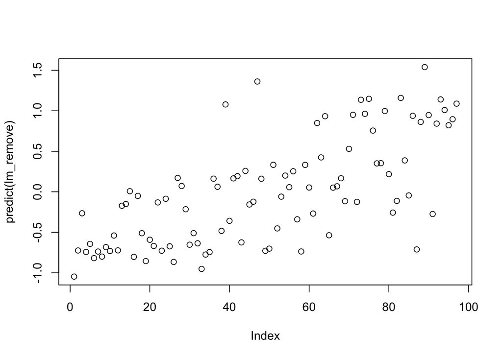

```r
plot(predict(lm_remove))
```

### 2. Best subset selection

#### (a) Describe the models implemented in

$$lm(lcavol ∼ 1, data=pro) \\
lm(lcavol ∼ ., data=pro[,c(1,4,9)])\\
lm(lcavol ∼ ., data=pro[,c(1,2,9)])$$
Compute their residual sums of squares.

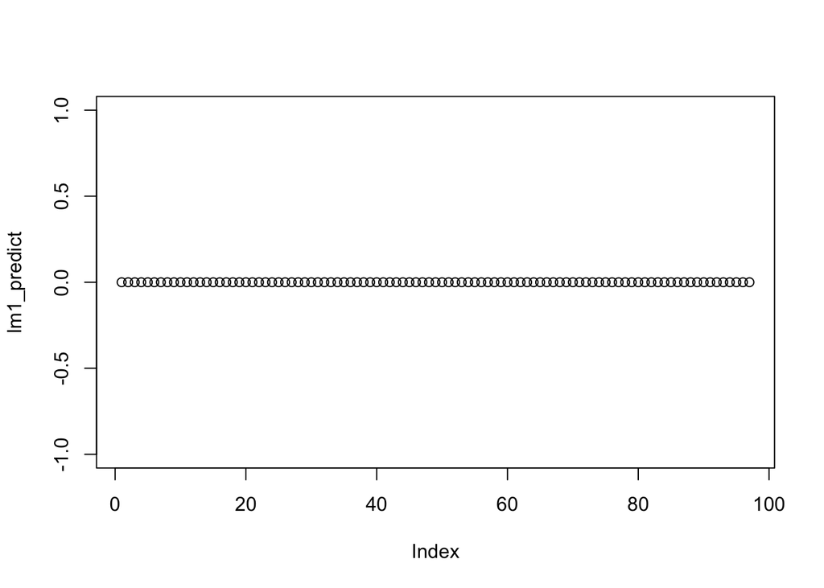

```r
lm1 = lm(lcavol~1, data=pro)
lm2 = lm(lcavol~., data=pro[,c(1,4,9)])
lm3 = lm(lcavol~., data=pro[,c(1,2,9)])
lm1_predict <- predict(lm1)
plot(lm1_predict)
```

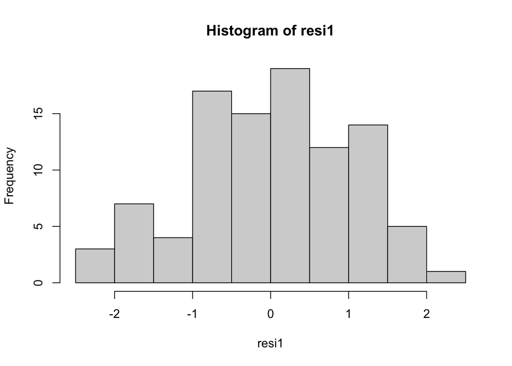

```r
resi1 =  pro$lcavol - lm1_predict
hist(resi1)
```

```r
print(sum(resi1)*sum(resi1))
```

```
## [1] 1.965994e-29
```

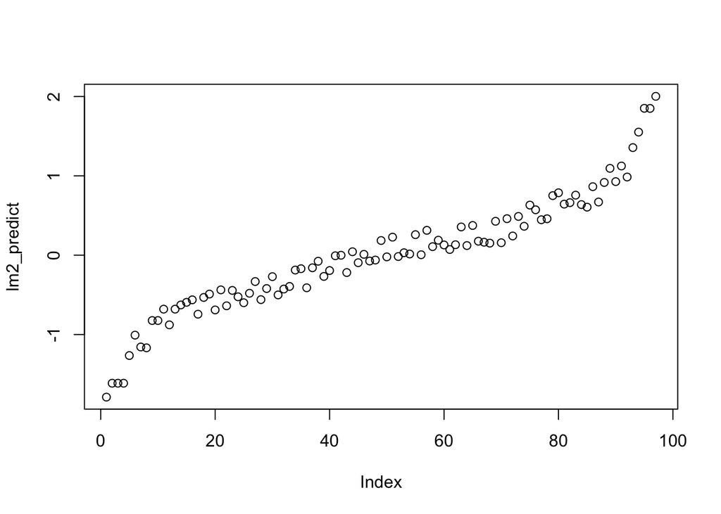

```r
lm2_predict <- predict(lm2)
plot(lm2_predict)
```

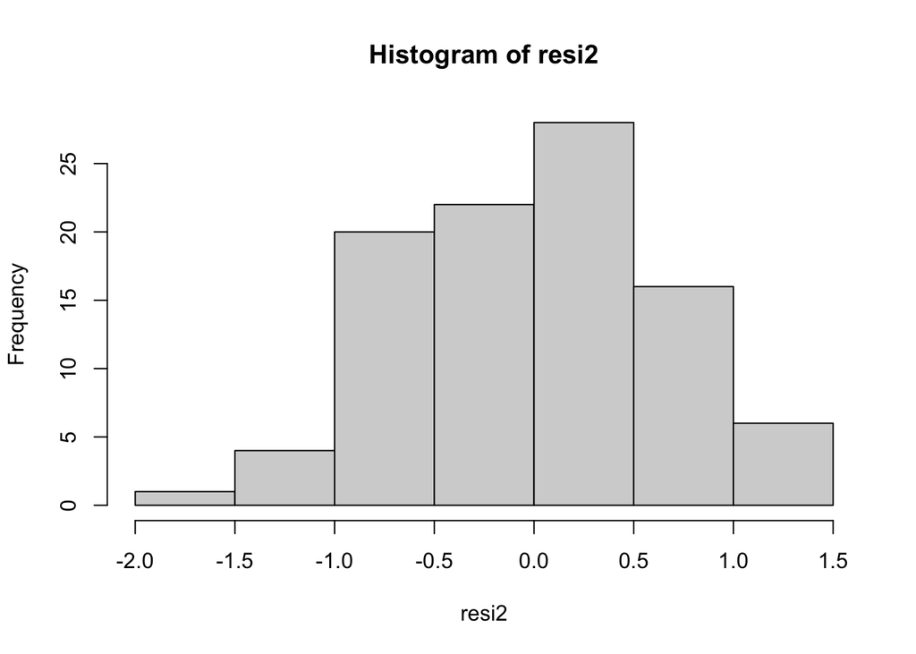

```r
resi2 =  pro$lcavol - lm2_predict
hist(resi2)
```

```r
print(sum(resi2)*sum(resi2))
```

```
## [1] 2.089718e-27
```

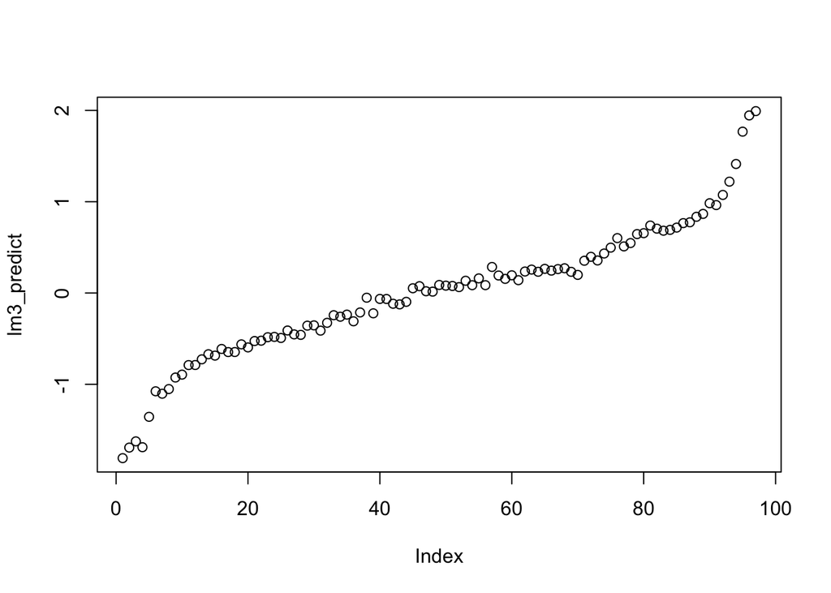

```r
lm3_predict <- predict(lm3)
plot(lm3_predict)
```

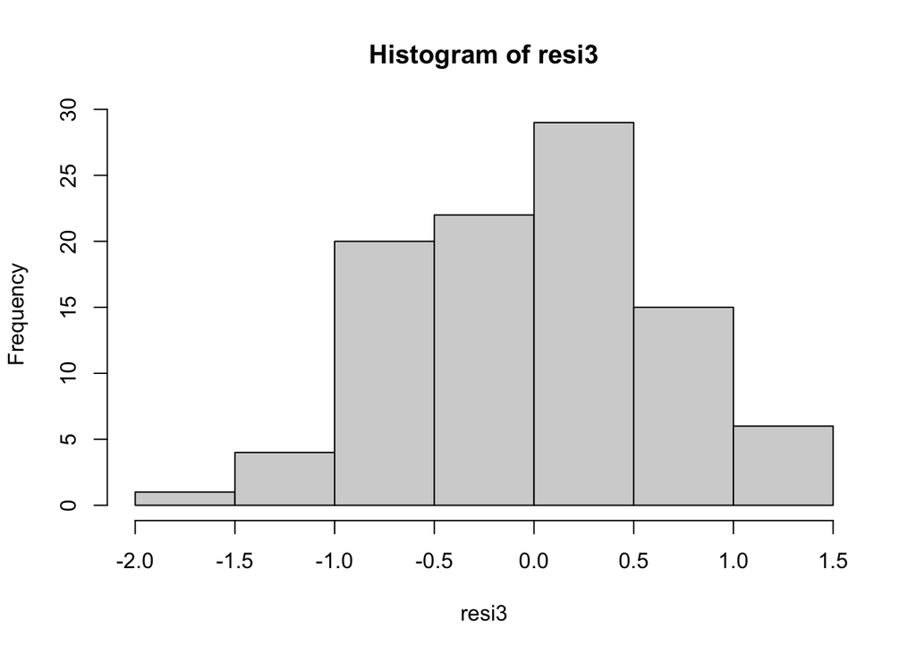

```r
resi3 =  pro$lcavol - lm3_predict
hist(resi3)
```

```r
print(sum(resi3)*sum(resi3))
```

```
## [1] 6.470911e-28
```

#### (b) Compute the residual sums of squares for all models of size k = 2.

```r
sub = combn(8,2)

for ( i in 1:28){
  set = c(1, sub[1,i]+1, sub[2,i]+1)
  fit = lm(lcavol ~.,data=pro[,set])
  print(set)
  print(sum(residuals(fit)^2))
}
```

```
## [1] 1 2 3
## [1] 86.67309
## [1] 1 2 4
## [1] 87.32923
## [1] 1 2 5
## [1] 64.3162
## [1] 1 2 6
## [1] 49.38799
## [1] 1 2 7
## [1] 66.34399
## [1] 1 2 8
## [1] 72.63042
## [1] 1 2 9
## [1] 44.04624
## [1] 1 3 4
```

[output cut: 41 more lines]

### What is the best choice of 2 predictors among 8?

The least RSS belongs to the combination of predictors 6 and 9 : Icp and Ipsa with the value of 34.03367

### (c) select the set of predictors that minimizes the residual sum of squares. Plot the residual sum of squares as a function of k.

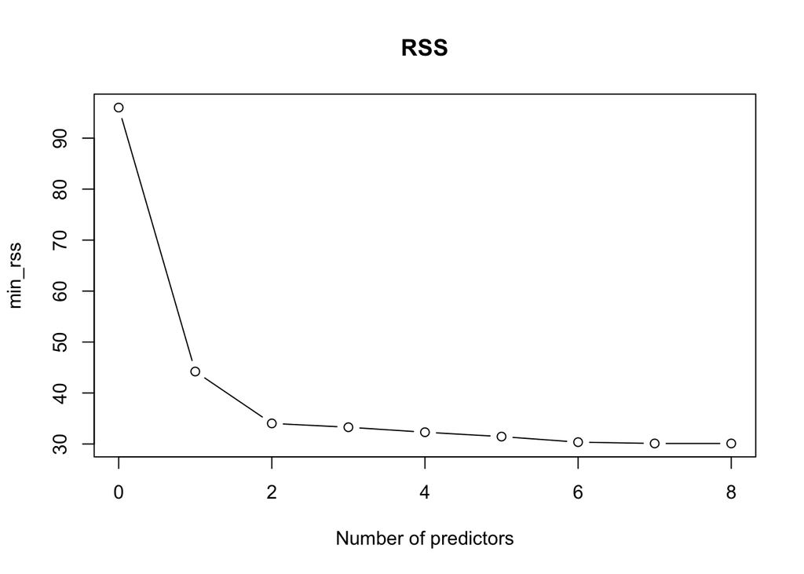

```r
min_rss <- 1:8
lowest <- list()
for (j in 1:8) {
  set1 = combn(8,j)
  rss <- 1:length(set1[1,])
  for (i in 1:length(set1[1,])) {
    vect = c(1,set1[,i]+1);

    fit2 = lm(lcavol ~ ., data=pro[,vect])
    rss[i] = sum(residuals(fit2)^2)
  }
  min_rss[j] = min(rss)
  lowest[j] = list(set1[,which.min(rss)]+1)
}
fit3 = lm(lcavol ~ 1, data=pro)
min_rss = c(sum(residuals(fit3)^2),min_rss)

plot(0:8,min_rss,type = "b",main ="RSS",xlab = "Number of predictors")
```

### The list of predictors minimalizing the RSS for each size of the regression model

```r
for (i in 1:8){
  print(paste("Number of predictors: ",i,". Predictors minimalizing RSS: ",lowest[i]))
}
```

```
## [1] "Number of predictors:  1 . Predictors minimalizing RSS:  9"
## [1] "Number of predictors:  2 . Predictors minimalizing RSS:  c(6, 9)"
## [1] "Number of predictors:  3 . Predictors minimalizing RSS:  c(3, 6, 9)"
## [1] "Number of predictors:  4 . Predictors minimalizing RSS:  c(3, 4, 6, 9)"
## [1] "Number of predictors:  5 . Predictors minimalizing RSS:  c(3, 6, 7, 8, 9)"
## [1] "Number of predictors:  6 . Predictors minimalizing RSS:  c(3, 4, 6, 7, 8, 9)"
## [1] "Number of predictors:  7 . Predictors minimalizing RSS:  c(3, 4, 5, 6, 7, 8, 9)"
## [1] "Number of predictors:  8 . Predictors minimalizing RSS:  c(2, 3, 4, 5, 6, 7, 8, 9)"
```

### (d) Do you think that minimizing the residual sum of squares is well suited to select the optimal size for the regression models? Could you suggest another possibility?

Minimizing the RSS is not the best factor for choosing the optimal regression. As seen in the example, RSS decreases when the size of the model increases, so it’s like we are always choosing the maximum possible size. One method could be to do anova test of this 8 models 2 by 2, and then conclude.

### 4. SPLIT-VALIDATION

#### Give a brief overview of split-validation: how it works? Why it is not subject to the same issues raised in question 3(c)

The split-validation method is used to overcome this issue:

Assuming we correctly separated the dataset into a training set and a test set, and fitted the model with the training set while evaluated with the test set, we obtained only a single sample point of evaluation with one test set. How can we be sure it is an accurate evaluation, rather than a value too low or too high by chance? If we have two models, and found that one model is better than another based on the evaluation, how can we know this is also not by chance? The reason we are concerned about this, is to avoid surprisingly low accuracy when the model is deployed and used on an entirely new data than the one we obtained, in the future. On the other hand,the model that just memorizes every training dataset and returns the previous y value as before would have 0 error on its training data. Cross validation like this lowers the accuracy of models for memorizing the peculiarities in the training data, thus reducing the types of effects from section 3.

The workflow of how this process works is as below :

step 0 : choosing random ( or non random) data for the training dataset  
step 1 : training dataset is used to train a few candidate models  
step 2 : validation dataset is used to evaluate the candidate models  
step 3 : one of the candidates is chosen  
step 4 : the chosen model is trained with a new training dataset  
step 5 : the trained model is evaluated with the test dataset

### 4. (b)

For this Model size of 2, we will use the variables 6 and 9 as mentioned before. let’s call this model $ M_2 $ for further references. The function metric, calculates the variance of residuals for the training dataset and afterwards the regression takes place.

```r
metric = function(fit, validation=F) {
  if (validation) {
    z = var(predict.lm(fit, pro[!!valid, ]) - pro[!!valid, 1])
  }
  else {
    z = var(predict.lm(fit, pro[!valid, ]) - pro[!valid, 1])
  }
  z
}

N = length(pro[,1])
valid = (1:N %% 3) == 0
fit = lm(lcavol ~ ., pro[!valid, c(1,6,9)])
summary(fit)
```

```
##
## Call:
## lm(formula = lcavol ~ ., data = pro[!valid, c(1, 6, 9)])
##
## Residuals:
##      Min       1Q   Median       3Q      Max
## -0.94991 -0.48654 -0.07584  0.52825  1.67197
##
## Coefficients:
##             Estimate Std. Error t value Pr(>|t|)
## (Intercept) -1.27029    0.20708  -6.134 6.59e-08 ***
## lcp          0.29464    0.08866   3.323   0.0015 **
## lpsa         0.51128    0.07881   6.488 1.64e-08 ***
## ---
## Signif. codes:  0 '***' 0.001 '**' 0.01 '*' 0.05 '.' 0.1 ' ' 1
##
## Residual standard error: 0.5903 on 62 degrees of freedom
## Multiple R-squared:  0.6682, Adjusted R-squared:  0.6575
## F-statistic: 62.43 on 2 and 62 DF,  p-value: 1.405e-15
```

```r
metric(fit)
```

```
##           [,1]
## [1,] 0.3375284
```

```r
metric(fit, validation = TRUE)
```

```
##           [,1]
## [1,] 0.4214062
```

The summary above is the for the mentioned model, as well as the variance of residuals for the training and validation dataset.

### (c) & (d)

For the next section, this Process is repeated for all the models, first for non random data selection and then for the random data selection.

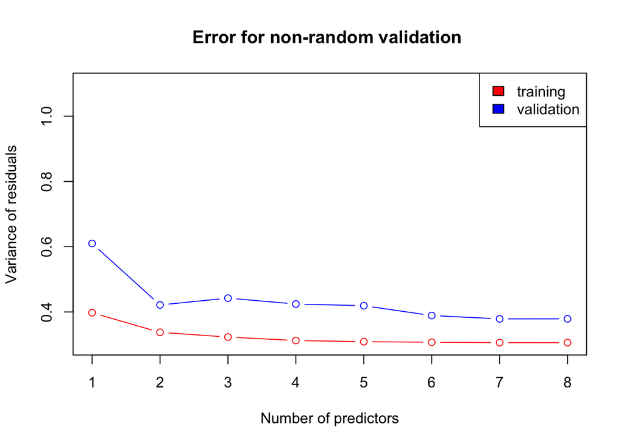

```r
N = length(pro[,1])
valid = (1:N %% 3) == 0


M = 7
res_training = 0:M
res_valid = 0:M
fit = lm(lcavol ~ 1, pro[!valid, ])


res_training[1] = metric(fit)
res_valid[1] = metric(fit, T)
best_indices = 1:M

for (k in 1:(M+1)) {
  combos = combn(1:(M+1),k)
  best_val = Inf
  best_ind = 1
  for (i in 1:length(combos[1,])) {
    fit = lm(formula = lcavol ~ ., pro[!valid,append(c(1),combos[,i]+1)])
    if (metric(fit) < best_val) {
      best_val = metric(fit)
      best_ind = i
    }
  }
best_indices[k] = best_ind
  res_training[k] = best_val
  fit = lm(formula = lcavol ~ ., pro[!valid,append(c(1),combos[,best_ind]+1)])
  res_valid[k] = metric(fit, T)
}

plot(1:(M+1), res_training, col="red", type = "b",main ="Error for non-random validation ",ylab = "Variance of residuals", xlab = "Number of predictors", ylim=c(0.3, 1.1))
lines(1:(M+1), res_valid, type = "b",col="blue")
legend("topright", c("training","validation"), fill=c("red","blue"))
```

As can be seen from the figure above, this model fit can be considered as a “good fit” since the validation error is somehow low and slightly higher than the training error

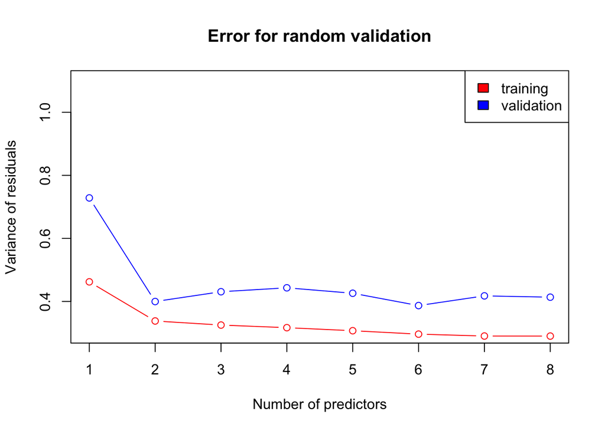

```r
N = length(pro[,1])
#valid = (1:N %% 3) == 0
valid = 1:N
for (i in 1:N) {valid[i] = F}
valid[sample(N, N/3)] = T

M = 7
residuals_training = 0:M
residuals_valid = 0:M
fit = lm(lcavol ~ 1, pro[!valid, ])


residuals_training[1] = metric(fit)
residuals_valid[1] = metric(fit, T)
best_indices = 1:M
for (k in 1:(M+1)) {
  combos = combn(1:(M+1),k)
  best_val = Inf
  best_ind = 1
  for (i in 1:length(combos[1,])) {
    fit = lm(formula = lcavol ~ ., pro[!valid,append(c(1),combos[,i]+1)])
    if (metric(fit) < best_val) {
      best_val = metric(fit)
      best_ind = i
    }
  }
  best_indices[k] = best_ind
  residuals_training[k] = best_val
  fit = lm(formula = lcavol ~ ., pro[!valid,append(c(1),combos[,best_ind]+1)])
  residuals_valid[k] = metric(fit, T)
}

plot(1:(M+1), residuals_training, col="red", type = "b",main ="Error for random validation",ylab = "Variance of residuals", xlab = "Number of predictors", ylim=c(0.3, 1.1))
lines(1:(M+1), residuals_valid, type = "b",col="blue")
legend("topright", c("training","validation"), fill=c("red","blue"))
```

Note: for some random selections, there might be an error, if so, please run the cell again

As can be seen from the figure above, from each run, we get different model fits , some can be considered a good fit and some are not. This shows the importance of choosing the validation set. which could be a potential drawback.

### (e) What is the main limitation with split- validation

So far, the limitation that we have observed, was on the data selection of the validation dataset. However, one other limitation that this method could have is that if we have a data set that is too small to be divided into these 3 sections. First of, if the training dataset is too small, the model will not have enough data to learn. On the other hand, if the validation set is too small, then the evaluation metrics like accuracy, precision, recall, and F1 score will have large variance and will not lead to the proper tuning of the model.

to compensate for this method, we could perform the k-fold cross validation.

In this method we shuffle the data set and then split it in to K equal parts. We now reserve the first part for testing and train model on rest of K-1 parts. After training, we then test model on first part that we had reserved and note the accuracy. Again in next iteration we now leave the second part for testing and train model on rest of data. We then test model on second part and note the accuracy. We carry out this process till we have done K iteration and have K accuracy score for each iteration.

### implementing K-fold Cross validation

```r
library("glmnet")
library("pls")
cv.k.fold = function(formula = lpsa ~ .,data,name,bestlam = 0, k){
  library(glmnet)
  library (pls)
  set.seed(1)
  # formula = as.formula(str.formula)

  length = nrow(data)
  size.fold = floor(length / k)
  index = seq(1,length)
  trunc_index = index
  # acc_error = vector("numeric",length = k)
  acc_error = 0
  for (i in 1:k){
    # Get length(data) / 10 random number in index
    sample = sample(trunc_index,size.fold,replace = F)
    # validation set: those data whose index obtained from sampling
    validation = data[sample,]

    # train set: the remaining data
    train = data[which(! index %in% sample),]

    # train data and predict model with validation set.
    # fit = 0
    # fit.pred = predict(model,validation)
    # if (name == "lm"){
    #
    # }
    if (name == "glm"){
      fit = glm(formula, data=train)
      fit.pred = predict(fit, s = bestlam, newdata = validation)
    }

    x = model.matrix(formula, train)[, -1]
    y = train$lpsa
    x.val = model.matrix(formula, validation)[, -1]

    if (name == "ridge"){
      fit = glmnet(x,y,alpha = 0,lambda = bestlam)
      fit.pred = predict(fit, s = bestlam, newx = x.val)
    }
    if (name == "lasso"){
      fit = glmnet(x,y,alpha = 1,lambda = bestlam)
      fit.pred = predict(fit, s = bestlam, newx = x.val)
    }
    if (name == "pcr"){
      fit = pcr(formula, data = train , scale =TRUE ,validation ="CV")
      fit.pred = predict(fit ,x.val, ncomp = bestlam)
    }
    if (name == "pls"){
      fit = plsr(formula, data = train , scale =TRUE ,validation ="CV")
      fit.pred = predict(fit ,x.val, ncomp = bestlam)
    }


    acc_error = acc_error + mean((fit.pred - validation[, 9])^2)


    # truncate index
    trunc_index = trunc_index[! trunc_index %in% sample]
  }

  MSE = acc_error / k
  return(MSE)
}

# Fit a linear model with all predictors using the usual least squares

model.LQ = lm(lcavol ~ .,pro)
summary(model.LQ)
```

```
##
## Call:
## lm(formula = lcavol ~ ., data = pro)
##
## Residuals:
##     Min      1Q  Median      3Q     Max
## -1.6242 -0.4110 -0.0226  0.4659  1.5277
##
## Coefficients:
##                           Estimate Std. Error t value Pr(>|t|)
## (Intercept)              -1.296150   0.201191  -6.442 6.51e-09 ***
## lweight                  -0.004088   0.076860  -0.053   0.9577
## age                       0.156545   0.071007   2.205   0.0301 *
## lbph                     -0.128263   0.071651  -1.790   0.0770 .
## svi1.89254797819741      -0.187014   0.217500  -0.860   0.3923
## lcp                       0.477810   0.100926   4.734 8.58e-06 ***
## gleason0.342627053981254  0.264441   0.182644   1.448   0.1513
## gleason1.72741139715549  -0.602896   0.643824  -0.936   0.3517
## gleason3.11219574032972   0.670387   0.413626   1.621   0.1087
## pgg45                    -0.225987   0.108634  -2.080   0.0405 *
## lpsa                      0.466283   0.076439   6.100 2.94e-08 ***
## ---
## Signif. codes:  0 '***' 0.001 '**' 0.01 '*' 0.05 '.' 0.1 ' ' 1
##
## Residual standard error: 0.5916 on 86 degrees of freedom
## Multiple R-squared:  0.6865, Adjusted R-squared:   0.65
## F-statistic: 18.83 on 10 and 86 DF,  p-value: < 2.2e-16
```

```r
# Estimate the test error using 10-fold cross validation
#err.LQ = cv.k.fold(data = pro,name = "pcr",k=10)
#err.LQ
```

### Conclusion

From the figures and errors, the conclusion is that the $M_2$ model is best, due to its simplicity. Even though other models have low validation error, $M_2$ is the smallest model that could give near optimal power. This model allows us to estimate lcavol directly via a simple formula that is easily interpretative. In addition, data collection is easier when there are far fewer measurements.